# 624: Forecasting Methods

Sean Connin

02/22/22

```r
library(fpp3) # datasets
library(tidyverse)
library(forecast)
library(tsibble)
library(flextable)
```

# 1 Forecasting Toolbox: Exercise 3.1

Produce forecasts for the following series using whichever of NAIVE(y), SNAIVE(y) or RW(y ~ drift()) is more appropriate in each case:

- Australian Population (global_economy):
- *Figure 1. I selected the drift method for Australian population owing to the monotonic increase and absence of seasonal variation in this series. This approach yielded better results (based on visual inspection) than the MEAN method.*
- Bricks (aus_production):
- *Figure 2. I selected the SNAIVE method to capture seasonal variation associated with this series. A NAIVE model could also be employed. However, it would not embed the variation as part of the forecast.*
- NSW Lambs (aus_livestock):
- *Figure 3. Similar to the previous example, I selected the SNAIVE method for this series.*
- Household wealth (hh_budget):
- *Figure 4. I selected the Drift method for this series owing to the absence of distinct seasonality across these series (i.e., Country) as well as the gradual upward trend in the data over the last ~8 years of record.*
- Australian takeaway food turnover (aus_retail):
- *Figure 5. I selected the Drift method in order to capture the overall series trend. An SNAIVE forecast reproduced recent seasonal patterns but did not adequately capture growth in food turnover beginning in 2014.*

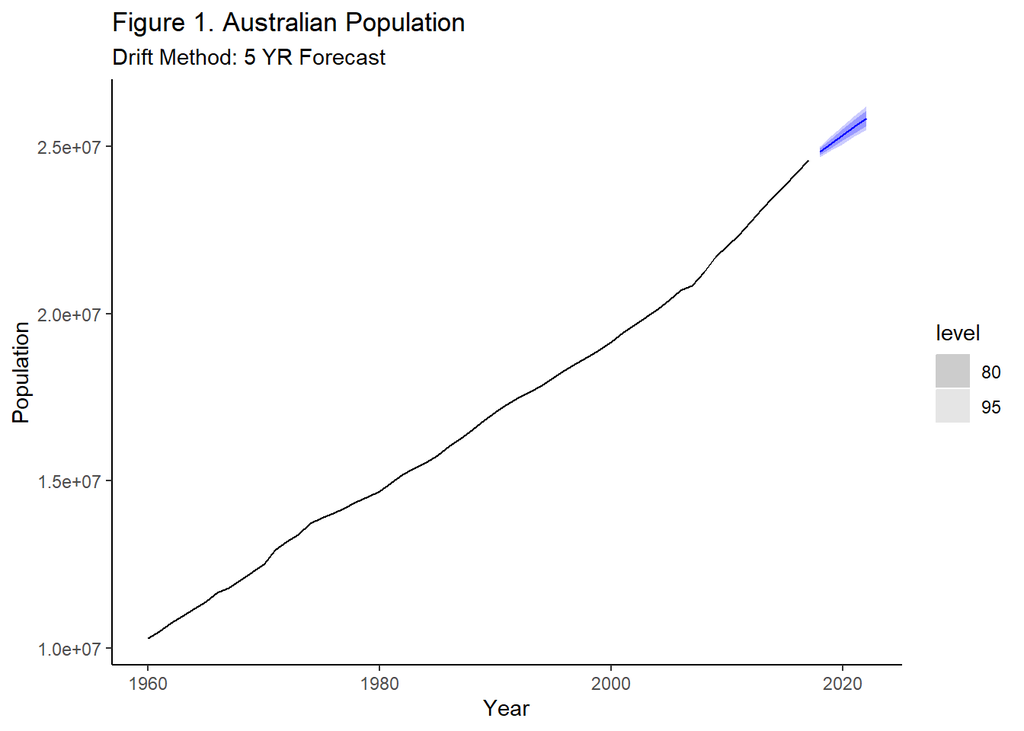

```r
# Subset australian population

aus_pop<-global_economy%>%
  select(Population, Year)%>%
  filter(Country %in% 'Australia')

# fit model

aus_popfit<-aus_pop%>%
  model(RW(Population ~ drift()))

# forecast 5 yrs

aus_popfc<-aus_popfit%>%
  forecast(h=5)

# plot  pop forecast

aus_popfc%>%
  autoplot(aus_pop)+ # include confidence intervals
  labs(title = 'Figure 1. Australian Population', subtitle = 'Drift Method: 5 YR Forecast')+
  theme_classic()
```

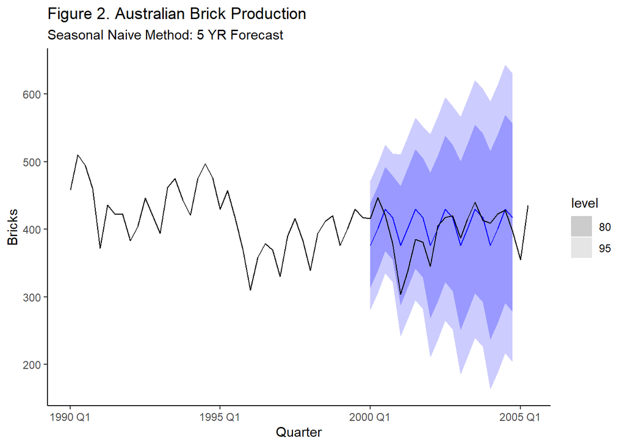

```r
#===========================================================

# subset Australian production - Bricks (SNAIVE)

aus_prod<- aus_production%>%
  select(c(Bricks, Quarter))%>%
  filter_index('1956 Q1' ~ '1999 Q4') # subset to exclude last 5 yrs

# fit model

aus_prodfit<-aus_prod%>%
  model(SNAIVE(Bricks ~ lag('year'))) # add 1 yr lag

# forecast 5 yrs

aus_prodfc<-aus_prodfit%>%
  forecast(h=20)  # h = Q, there are 4 per year

# plot pop forecast with data overlap

limited<-aus_production%>%    # last 15 yrs of record for comparative purposes
  select(c(Bricks, Quarter))%>%
  filter_index('1990 Q1' ~ '2005 Q2')

aus_prodfc%>%
  autoplot(limited)+
  labs(title = 'Figure 2. Australian Brick Production', subtitle = 'Seasonal Naive Method: 5 YR Forecast')+
  theme_classic()
```

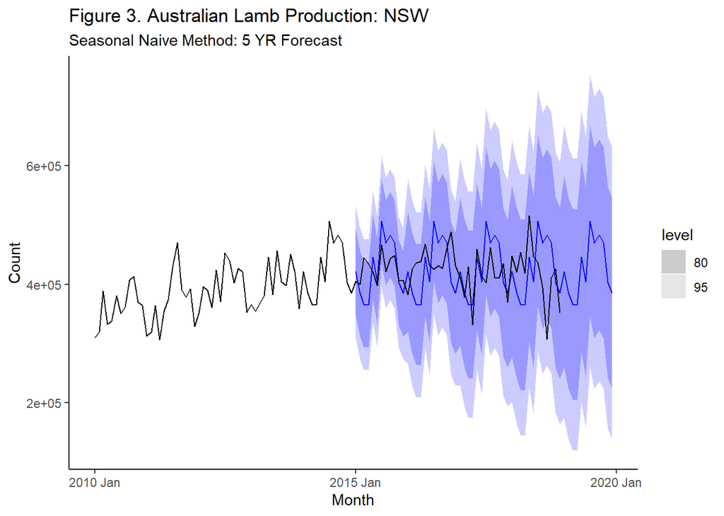

```r
# ============================================================


# subset Australian livestock - Lambs, NSW

aus_live<-aus_livestock%>%
  filter(Animal %in% 'Lambs', State %in% 'New South Wales')%>%
  filter_index('1972 Jul' ~ '2014 Dec') # exclude last 3 yrs of data

# fit model (SNAIVE)

aus_livefit<-aus_live%>%
  model(SNAIVE(Count)) #  1 yr lag default

# forecast 5 yrs

aus_livefc<-aus_livefit%>%
  forecast(h=60)  # h = mo, there are 12 per year

# create plot with data overlap

limited2<-aus_livestock%>%    # last 8 yrs of record for comparative purposes
  filter(Animal %in% 'Lambs', State %in% 'New South Wales')%>%
  filter_index('2010 Jan' ~ '2018 Dec')

aus_livefc%>%
  autoplot(limited2)+
  labs(title = 'Figure 3. Australian Lamb Production: NSW', subtitle = 'Seasonal Naive Method: 5 YR Forecast')+
  theme_classic()
```

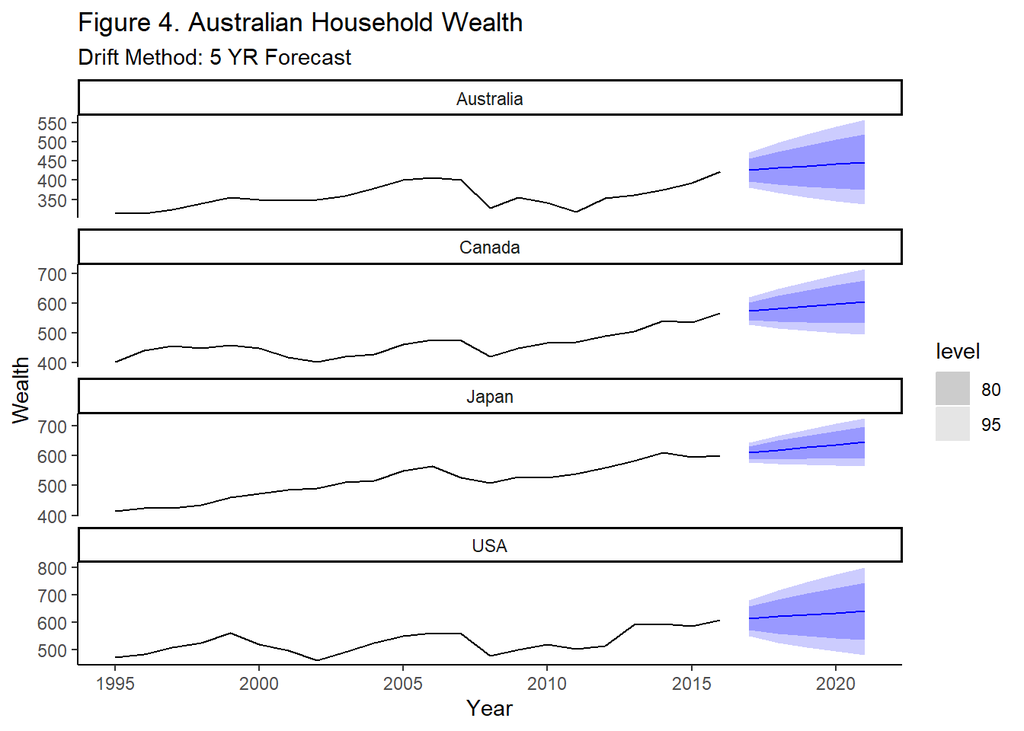

```r
#=============================================================

# subset Austrailian household wealth

hh_wealth<-hh_budget#%>%
  #select(c(Country, Year, Wealth))%>%
  #filter(Country %in% 'Australia')

# fit model (Drift)

hh_fit<-hh_wealth%>%
  model(RW (Wealth ~ drift()))

# forecast 5 yrs

hh_fc<-hh_fit%>%
  forecast(h=5)  # h = yr

# create plot

hh_fc%>%
  autoplot(hh_wealth)+
  labs(title = 'Figure 4. Australian Household Wealth', subtitle = 'Drift Method: 5 YR Forecast')+
  theme_classic()
```

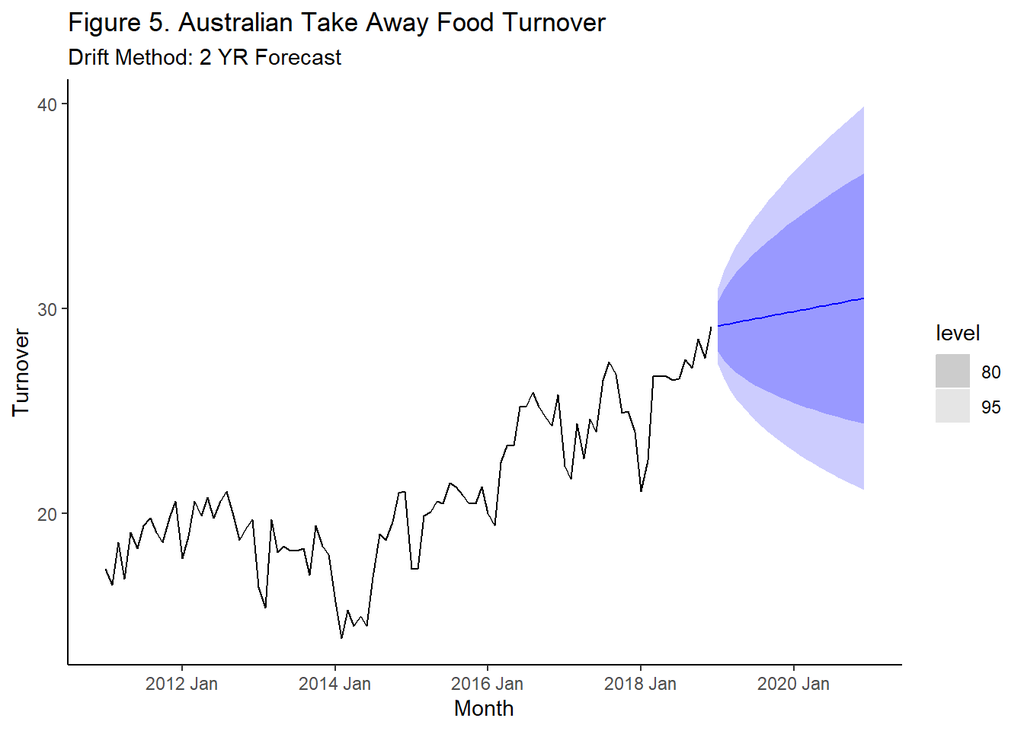

```r
#============================================================

# subset Australian Capital Area takeaway food turnover

aus_food<-aus_retail%>%
  select(c(State, Industry, Month, Turnover))%>%
  filter(Industry %in% 'Takeaway food services', State %in% 'Australian Capital Territory')

# fit model (SNAIVE)

aus_foodfit<-aus_food%>%
  model(RW(Turnover ~drift())) #  1 yr lag default

# forecast 2 yrs

aus_foodfc<-aus_foodfit%>%
  forecast(h=24)  # h = mo, there are 12 per year

# create plot with data overlap

limited3<-aus_retail%>%    # last ~10 yrs of record for comparative purposes
  select(c(State, Industry, Month, Turnover))%>%
  filter(Industry %in% 'Takeaway food services', State %in% 'Australian Capital Territory')%>%
  filter_index('2011 Jan' ~ '2018 Dec')

aus_foodfc%>%
  autoplot(limited3)+
  labs(title = 'Figure 5. Australian Take Away Food Turnover', subtitle = 'Drift Method: 2 YR Forecast')+
  theme_classic()
```

# 2 Forecasting Toolbox: Exercise 3.2

Use the Facebook stock price (data set gafa_stock) to do the following:

- Produce a time plot of the series:
- *See Figure 6.*
- Produce forecasts using the drift method and plot them:
- *See Figure 7.*
- Show that the forecasts are identical to extending the line drawn between the first and last observations:
- *See Figure 7. The mean 30 day forecast (blue line) extends the line segment connecting the first and last observations in 2018 (red).*
- Try using some of the other benchmark functions to forecast the same data set. Which do you think is best? Why?
- *See Figure 8. Among forecasts produced by the Mean, Naive, and Drift methods, the latter produced the best result. Neither the Mean or Naive forecasts continued the downward trend observed over the last ~ 100 days of record. Nonetheless, if a seasonal increase in the data is expected, the Mean method may be a better option.*

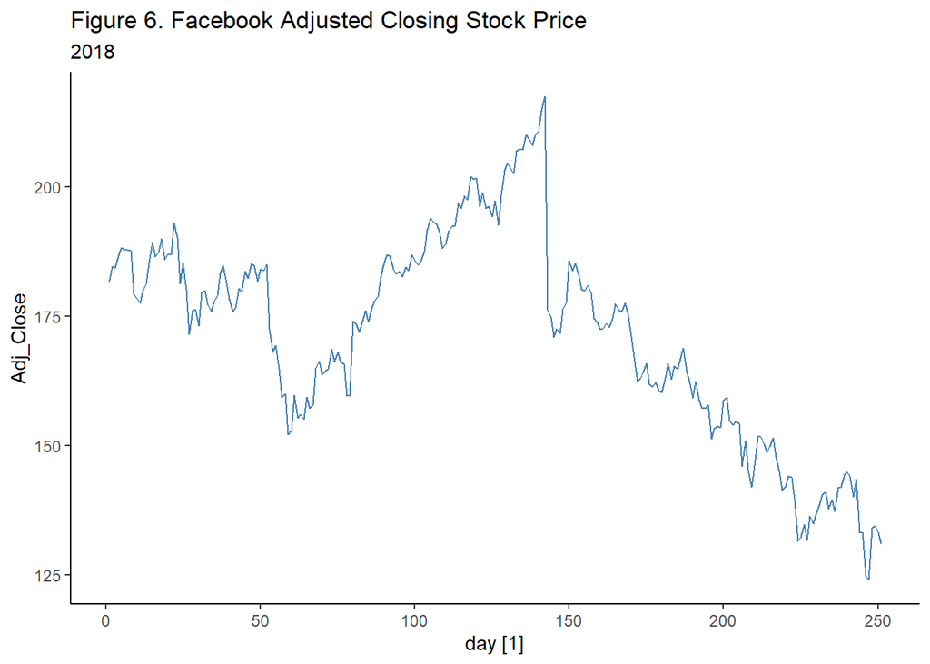

```r
#plot time series of adjusted closing stock, adjust for trading days, restrict to 2018

fb<-gafa_stock%>%
  select(Symbol, Date, Adj_Close)%>%
  filter(Symbol %in% 'FB')%>%
  filter(Date > '2018-01-01')%>%
  mutate(day = row_number()) %>%
  update_tsibble(index = day, regular = TRUE)


fb%>%
  autoplot(color = 'steelblue')+
  labs(title = 'Figure 6. Facebook Adjusted Closing Stock Price', subtitle = '2018')+
  theme_classic()
```

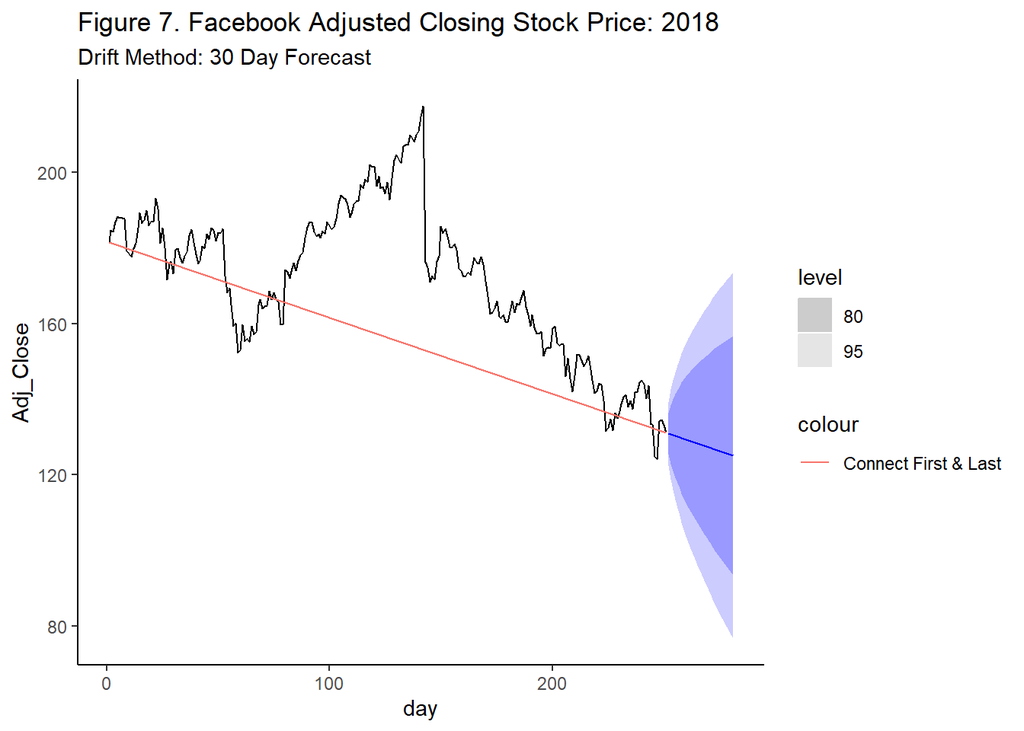

```r
# fit model -- Note 1 day intervals

fb_fit<-fb%>%
  model(RW(Adj_Close ~ drift()))

# forecast 1 yrs

fb_fc<-fb_fit%>%
  forecast(h=30)  # h = day

# create plot

fb_fc%>%
  autoplot(fb)+
  geom_segment(aes(x = 1, y = 181.42, xend = 251, yend = 131.09, colour = "Connect First & Last"), data = fb)+
  labs(title = 'Figure 7. Facebook Adjusted Closing Stock Price: 2018', subtitle = 'Drift Method: 30 Day Forecast')+
  theme_classic()
```

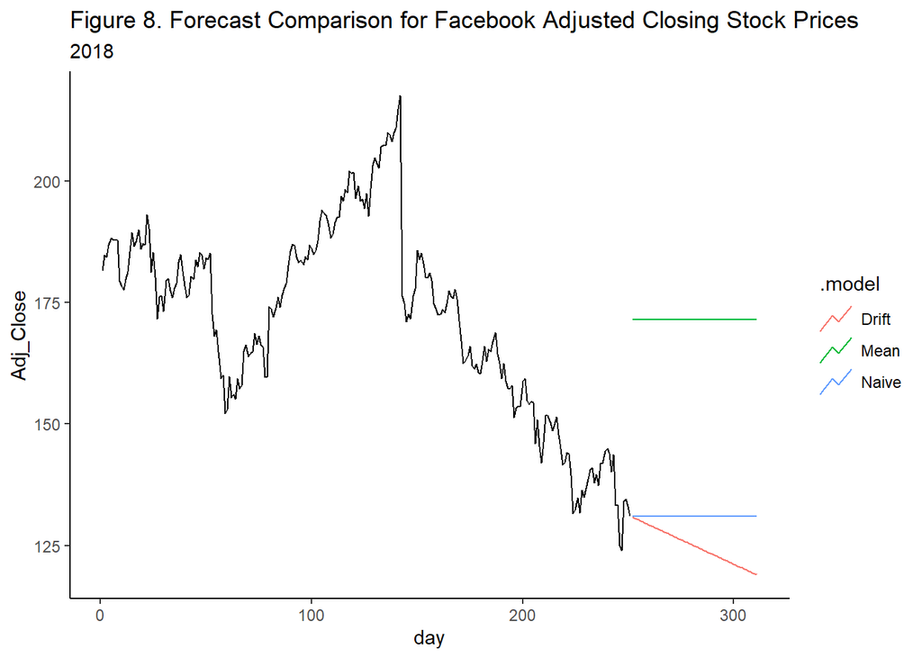

```r
# Model and plot other benchmarks

mult_fit <- fb %>%
  model(
    Drift = RW(Adj_Close ~ drift()),
    Mean = MEAN(Adj_Close),
    Naive = NAIVE(Adj_Close)
  )

# Generate forecasts for 60 days

mult_fc <- mult_fit %>% forecast(h = 60)

# Plot forecasts against actual values

mult_fc %>%
  autoplot(fb, level = NULL) +
  labs(
    y = "Adj_Close",
    title = "Figure 8. Forecast Comparison for Facebook Adjusted Closing Stock Prices", subtitle = '2018'
  ) +
  theme_classic()
```

# 3 Forecasting Toolbox: Exercise 3.3

Apply a seasonal naïve method to the quarterly Australian beer production data from 1992. Check if the residuals look like white noise, and plot the forecasts. What do you conclude?

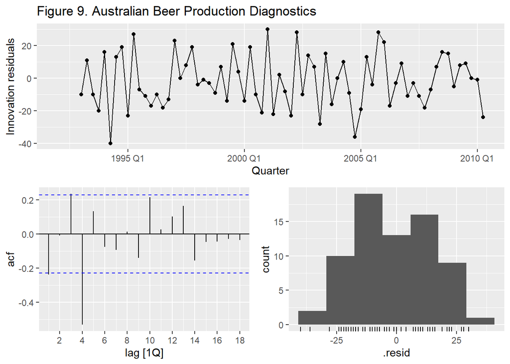

```r
# Extract data of interest

recent_production <- aus_production %>%
  filter(year(Quarter) >= 1992)

# Define and estimate a model

fit <- recent_production %>% model(SNAIVE(Beer))

# Look at the residuals  --- check using a box test?

fit %>% gg_tsresiduals()+
  labs(title='Figure 9. Australian Beer Production Diagnostics')
```

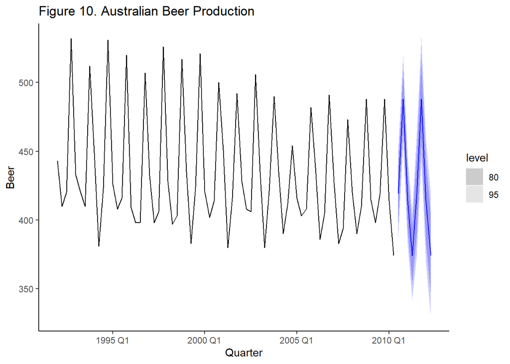

```r
# Look a some forecasts

fit %>% forecast() %>%
  autoplot(recent_production)+
  labs(title='Figure 10. Australian Beer Production')+
  theme_classic()
```

# 4 Forecasting Toolbox: Exercise 3.4

Repeat the previous exercise using the Australian Exports series from global_economy and the Bricks series from aus_production. Use whichever of NAIVE() or SNAIVE() is more appropriate in each case.

- *Global Economy: Australian Exports - the residuals for this series are normally distributed and homoscedastic (Figure 11). There is a hint of autocorrelation at 4-Yr lag intervals. This feature, however, is not consistent across the lag series. Similarly, inter-annual seasonality (Figure 12) is irregular. The NAIVE method is appropriate for this series.*
- _Australian Production: Bricks (Figure 13 & 14) - *there is periodic autocorrelation within the lag series (Figure 13) and the residuals are skewed (left tail). A plot the innovation residuals points to a 5-yr cycle of increasing-decreasing values (~1990 on). The SNAIVE method is appropriate for this series but does not replicate the more recent 5-yr cycle.*

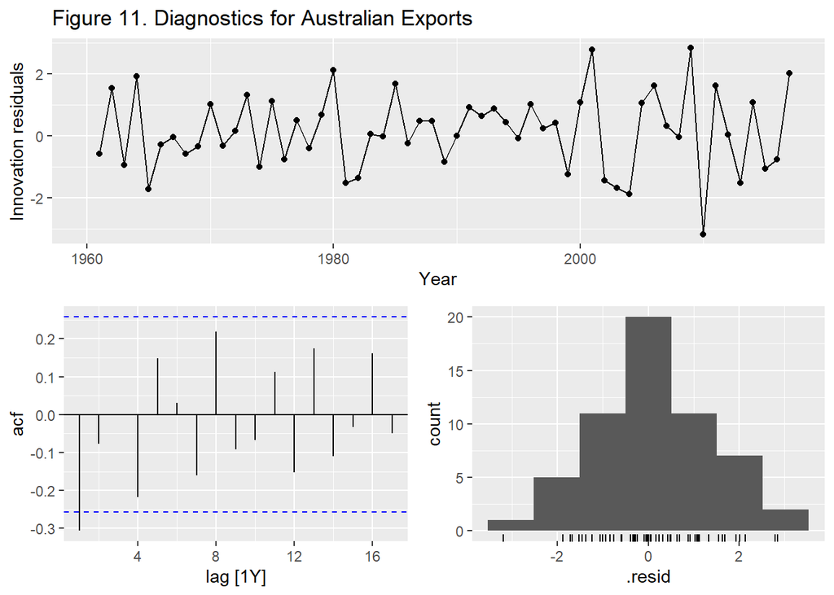

```r
# Extract data of interest

aus_exp <- global_economy %>%
  select(c(Country, Year, Exports))%>%
  filter(Country %in% 'Australia')

# Define model

aus_fit <- aus_exp %>% model(NAIVE(Exports)) # NAIVE - annual data

# Plot residuals

aus_fit %>% gg_tsresiduals()+
  labs(title='Figure 11. Diagnostics for Australian Exports')
```

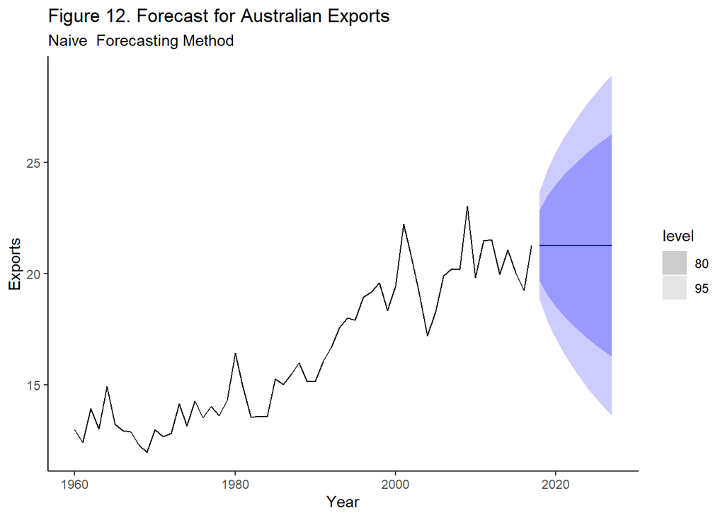

```r
# Forecast

aus_fit %>% forecast(h=10) %>%
  autoplot(aus_exp)+
  labs(title='Figure 12. Forecast for Australian Exports', subtitle="Naive  Forecasting Method")+
  theme_classic()
```

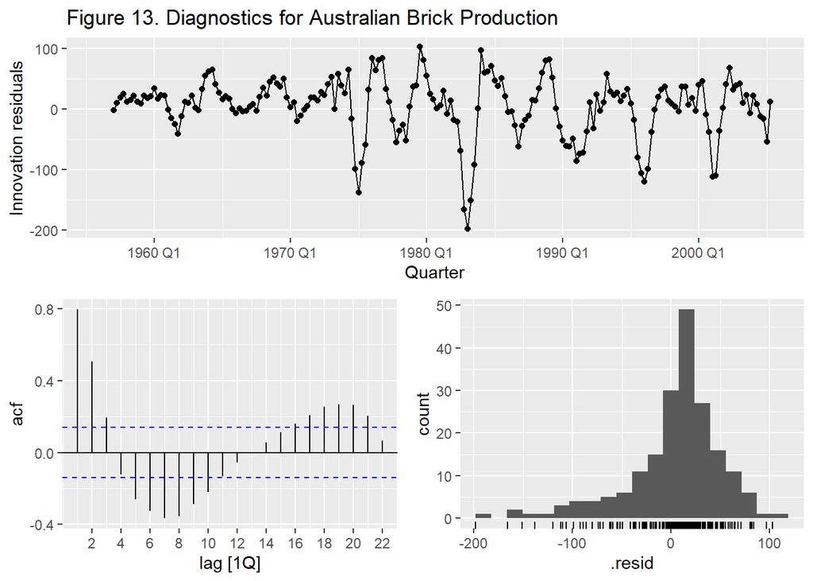

```r
# Extract Australian Brick Production

aus_prod <- aus_production %>%
  select(Bricks)%>%
  drop_na(Bricks) # a dim() check indicates gaps (scan_gaps()?)

# Define and estimate a model

ausprod_fit <- aus_prod%>% model(SNAIVE(Bricks))

# Plot residuals

ausprod_fit %>% gg_tsresiduals()+
  labs(title='Figure 13. Diagnostics for Australian Brick Production')
```

[figure not shown]

```r
# Plot forecast 2 yrs

ausprod_fit%>%
  forecast(h=16)%>%
  autoplot(aus_prod)+
  labs(title='Figure 14. Forecast for Australian Brick Production from 1980', subtitle='SNAIVE Method')+
  theme_classic()
```

# 5 Forecasting Toolbox: Exercise 3.7

For your retail time series (from Exercise 8 in Section 2.10) create a training dataset consisting of observations before 2011.

*Dataset = Turnover in the Pharmaceutical, Cosmetic, and Toiletry Industry. Turnover has been log transformed to reduce changes in seasonal variance over time.*

```r
# replicate dataset used in HW2

set.seed(124566791)

# load data

myseries <- aus_retail %>%
  filter(`Series ID` == sample(aus_retail$`Series ID`,1))

#log transform Turnover

myseries<-myseries%>%
  mutate(Turnover = log(Turnover))

myseries_train <- myseries %>%
  filter(year(Month) < 2011)
```

Check that your data have been split appropriately by producing the following plot.

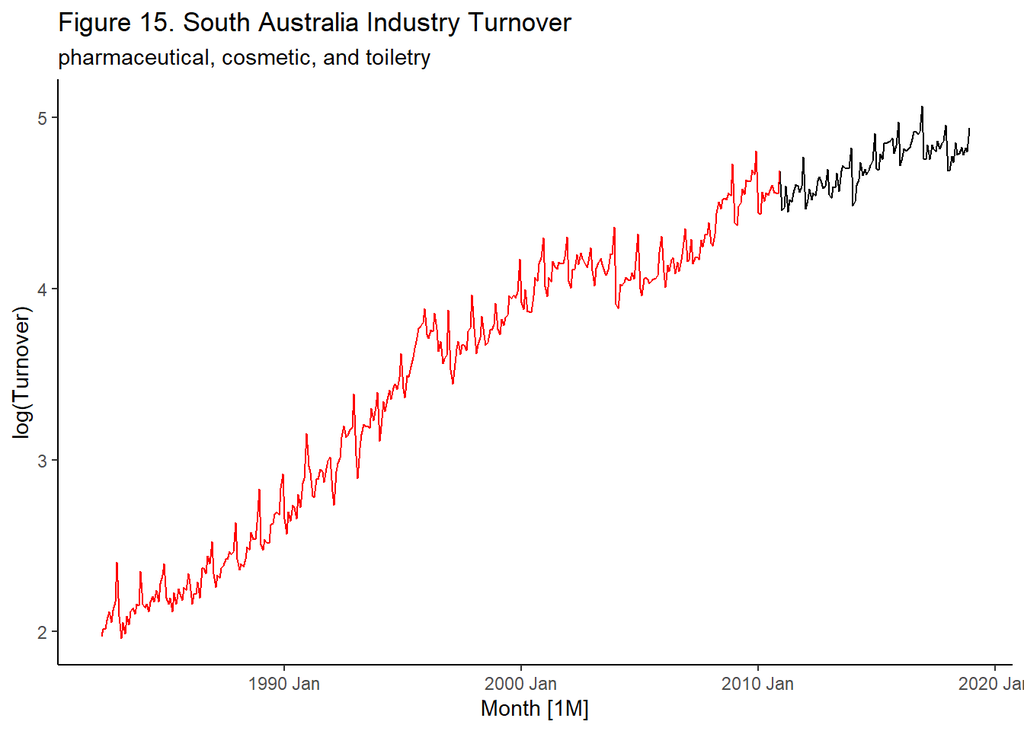

```r
autoplot(myseries, Turnover) +
  autolayer(myseries_train, Turnover, colour = "red")+
  labs(title='Figure 15. South Australia Industry Turnover', subtitle='pharmaceutical, cosmetic, and toiletry', y = 'log(Turnover)')+
  theme_classic()
```

Fit a seasonal naïve model using SNAIVE() applied to your training data (myseries_train).

*Note: due to an increase in the seasonal variance over time, I log-transformed the Turnover series.*

```r
# fit the model

fit <- myseries_train %>%
  model(SNAIVE(Turnover))
```

Check the residuals. Do the residuals appear to be uncorrelated and normally distributed?

*There are indications of pattern in the residuals (log transformed data), particularly between 1995-2005, when the data showed a rapid increase in seasonal variation and trend. There is also autocorrelation in the lag series. It appears that the model did not capture these latter effects completely.*

*The residuals are approximately normally distributed. This was not the case prior to transforming the data.*

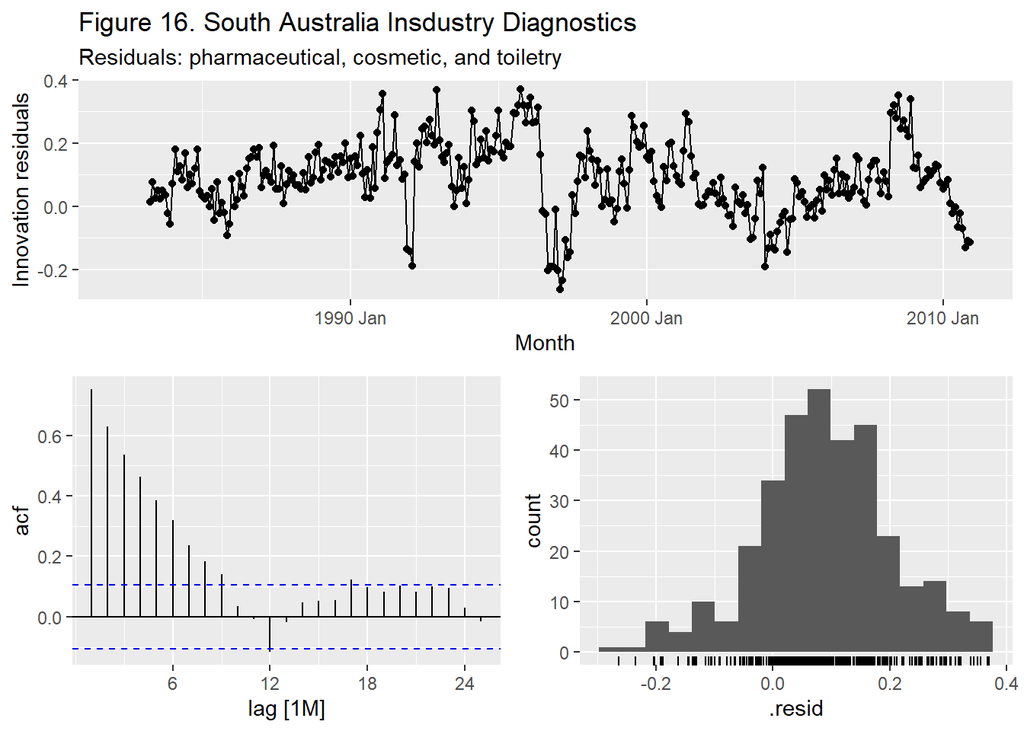

```r
# plot model diagnostics

fit %>% gg_tsresiduals()+
  labs(title='Figure 16. South Australia Insdustry Diagnostics', subtitle='Residuals: pharmaceutical, cosmetic, and toiletry')
```

Produce forecasts for the test data

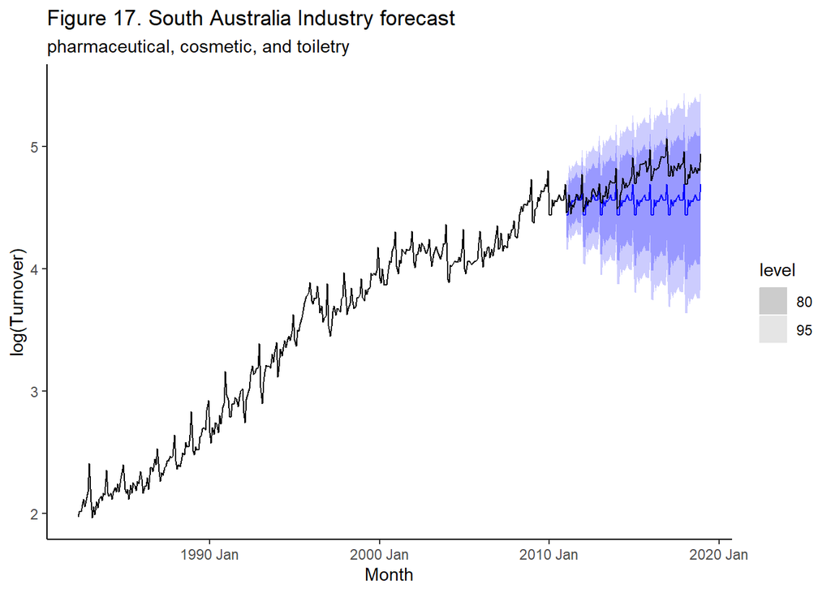

```r
fc <- fit %>%
  forecast(new_data = anti_join(myseries, myseries_train))

fc %>% autoplot(myseries)+
  labs(title='Figure 17. South Australia Industry forecast', subtitle='pharmaceutical, cosmetic, and toiletry', y = 'log(Turnover)')+
  theme_classic()
```

6. Compare the accuracy of your forecasts against the actual values.

*Forecast accuracy (MAPE) for training and test sets was 3.50 and 3.63, respectively, indicating a slight reduction in model accuracy with the test set. The general consistency of these values indicates suggests that the model was not under- or over-fit with regard to the training data.*

```r
# calculate accuracy of train and test

fit1<-fit %>% accuracy()

fc1<-fc %>% accuracy(myseries)

# combine into single table

flextable(rbind(fit1, fc1))
```

| State | Industry | .model | .type | ME | RMSE | MAE | MPE | MAPE | MASE | RMSSE | ACF1 |
| --- | --- | --- | --- | --- | --- | --- | --- | --- | --- | --- | --- |
| South Australia | Pharmaceutical, cosmetic and toiletry goods retailing | SNAIVE(Turnover) | Training | 0.08874908 | 0.1448040 | 0.1171398 | 2.715744 | 3.509398 | 1.00000 | 1.000000 | 0.7516720 |
| South Australia | Pharmaceutical, cosmetic and toiletry goods retailing | SNAIVE(Turnover) | Test | 0.17065372 | 0.2067273 | 0.1740920 | 3.554163 | 3.630709 | 1.48619 | 1.427635 | 0.9228345 |

7. How sensitive are the accuracy measures to the amount of training data used?

*The comparative sensitivity of accuracy measures to the amount of training data will depend, in part, on the forecasting method. For example, the SNAIVE model constructs a forecast equal to the last observed value from the same season. The amount of training data preceding that season is not taken into account. This is demonstrated below (See Figures 16 & 17). If we restrict our Turnover data to the last two years of record, the MAPE scores decrease to 1.04 (training) and 0.79 (test), indicating an increase in forecast accuracy. Other methods will generate accuracy measures that are more sensitive to the long-term record (e.g., MEAN, Drift).*

*The sensitivity of accuracy measures will also depend on aspects of seasonality and trend in the data. For example, model accuracy will be less sensitive to the amount of training data for a series that is stationary, relative to one that is not.*

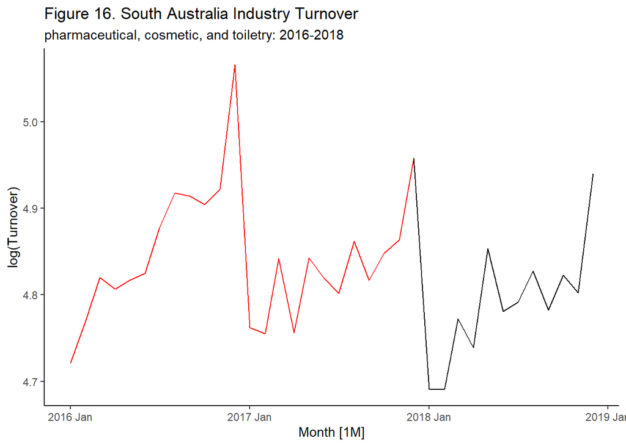

```r
# restrict analysis to last 2 years of record

my_short <- myseries %>%
  filter_index('2016 Jan' ~ .)

#create trainset from 2016-17

short_train <- my_short %>%
  filter_index('2016 Jan' ~ '2017 Dec')

#plot series and train set

autoplot(my_short, Turnover) +
  autolayer(short_train, Turnover, colour = "red")+
  labs(title='Figure 16. South Australia Industry Turnover', subtitle='pharmaceutical, cosmetic, and toiletry: 2016-2018', y = 'log(Turnover)')+
  theme_classic()
```

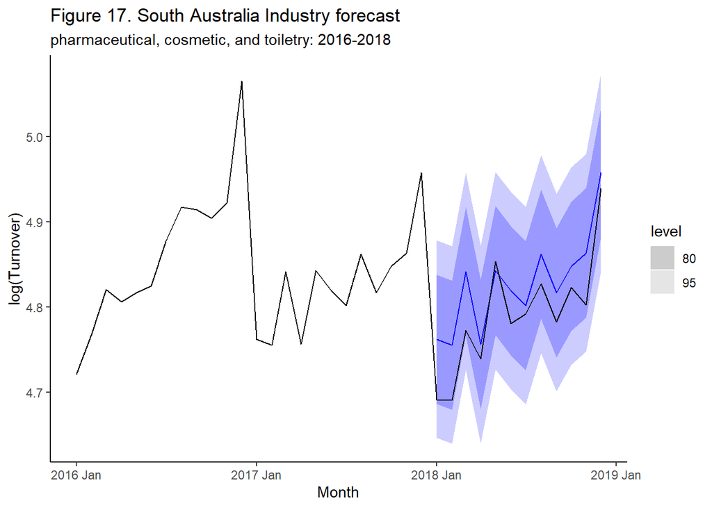

```r
#fit model

short_fit <- short_train %>%
  model(SNAIVE(Turnover))

short_fc <- short_fit %>%
  forecast(new_data = anti_join(my_short, short_train))

# plot forecast with emphasis on last 5 yrs of series

short_fc %>% autoplot(my_short)+
  labs(title='Figure 17. South Australia Industry forecast', subtitle='pharmaceutical, cosmetic, and toiletry: 2016-2018', y = 'log(Turnover)')+
  theme_classic()
```

```r
# calculate accuracy of train and test

short_fit1<-short_fit %>% accuracy()

short_fc1<-short_fc %>% accuracy(my_short)

# combine into single table

flextable(rbind(short_fit1, short_fc1))
```

| State | Industry | .model | .type | ME | RMSE | MAE | MPE | MAPE | MASE | RMSSE | ACF1 |
| --- | --- | --- | --- | --- | --- | --- | --- | --- | --- | --- | --- |
| South Australia | Pharmaceutical, cosmetic and toiletry goods retailing | SNAIVE(Turnover) | Training | -0.03607393 | 0.05920387 | 0.05075744 | -0.7425382 | 1.0481485 | 1.0000000 | 1.0000000 | 0.2746252 |
| South Australia | Pharmaceutical, cosmetic and toiletry goods retailing | SNAIVE(Turnover) | Test | -0.03620437 | 0.04397112 | 0.03803446 | -0.7600463 | 0.7977521 | 0.7493375 | 0.7427068 | 0.1837584 |